# OB sniff-locked gamma — ridge & phase-continuity analysis (V2)

## cueTask — cr

### Group mean TFR & peak-aligned TFR

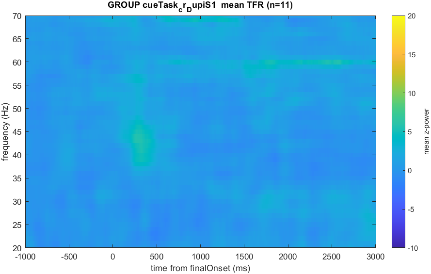

DupiS1 cr mean TFR

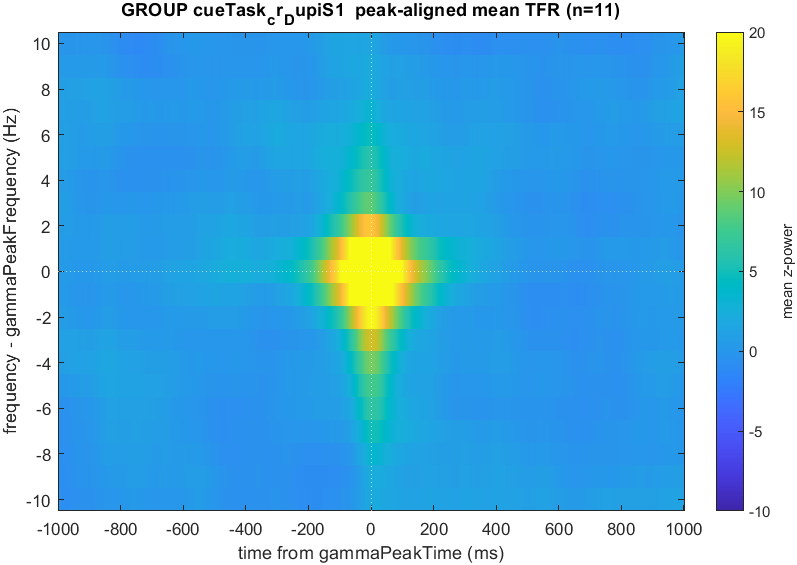

DupiS1 cr peak-aligned

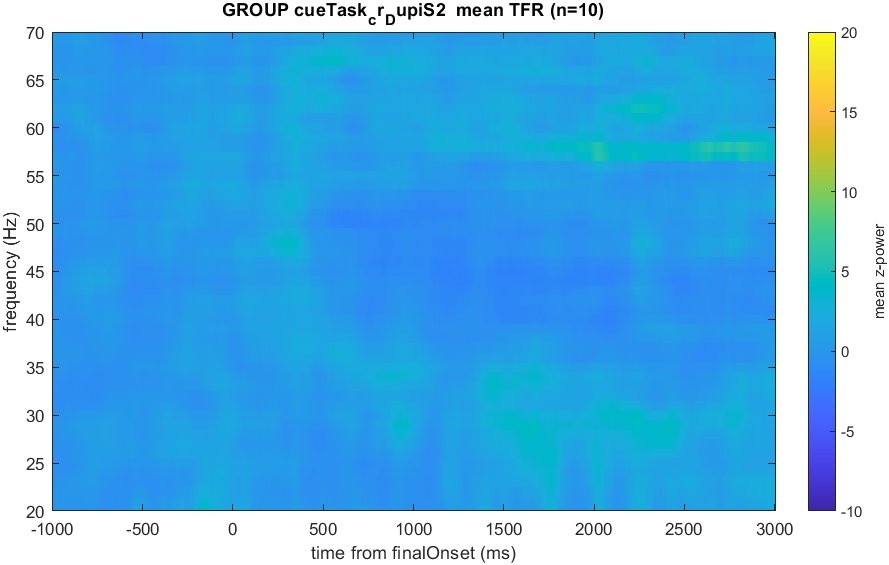

DupiS2 cr mean TFR

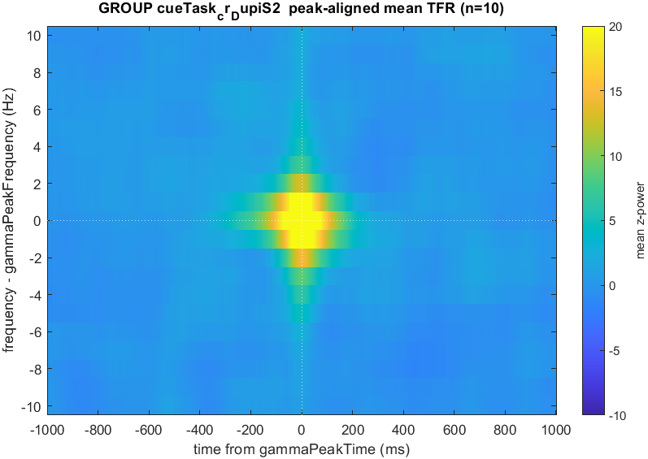

DupiS2 cr peak-aligned

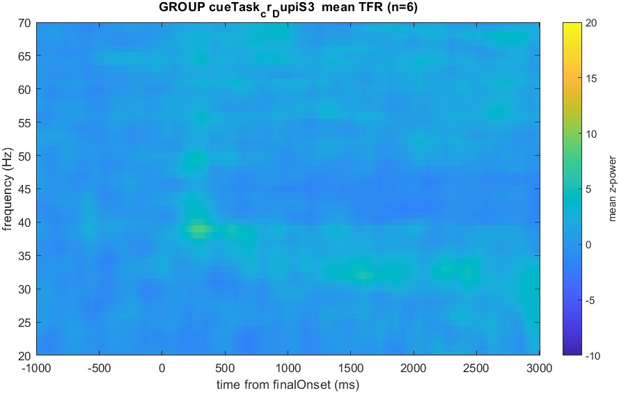

DupiS3 cr mean TFR

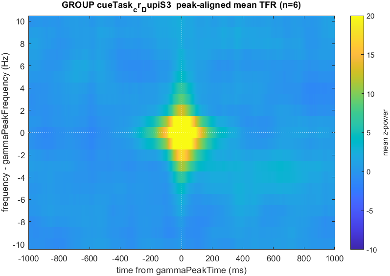

DupiS3 cr peak-aligned

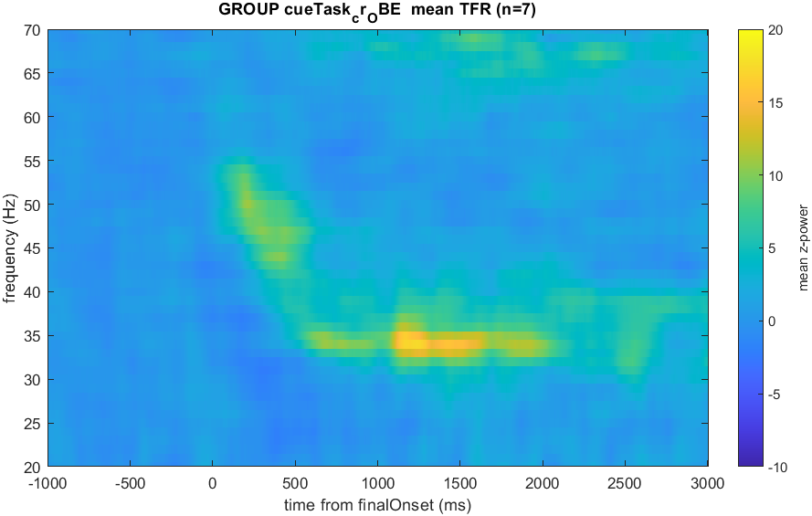

OBE cr mean TFR

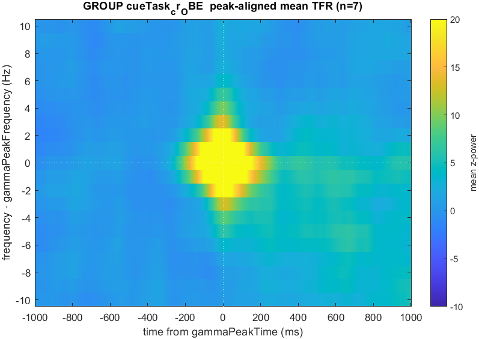

OBE cr peak-aligned

### Single-trial examples (TFR + primary/secondary ridge)

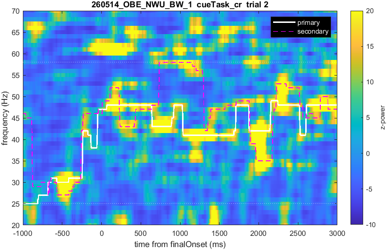

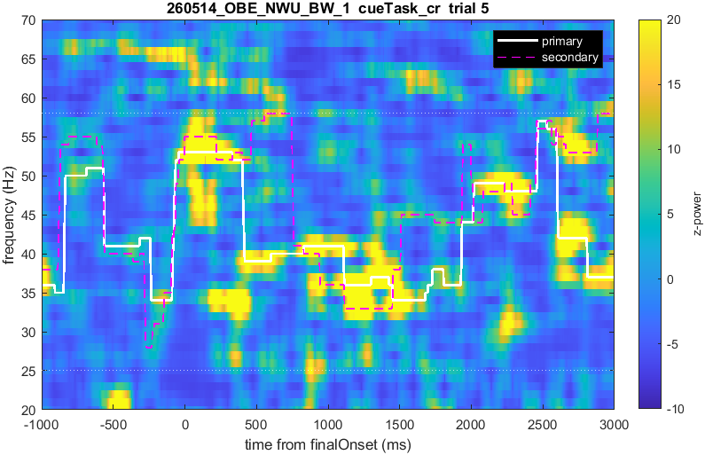

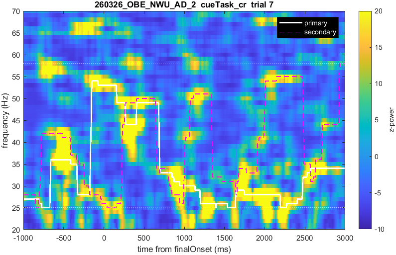

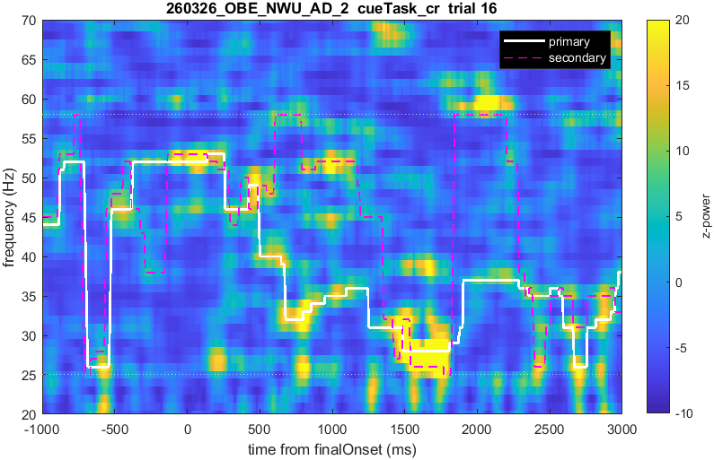

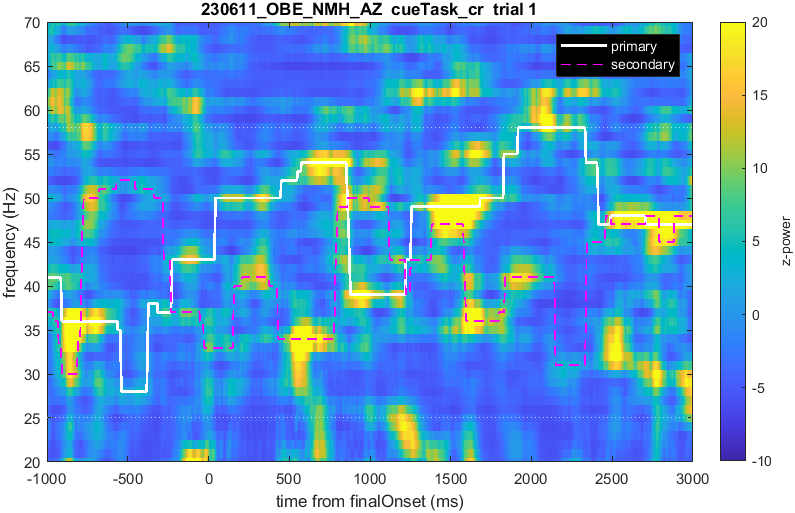

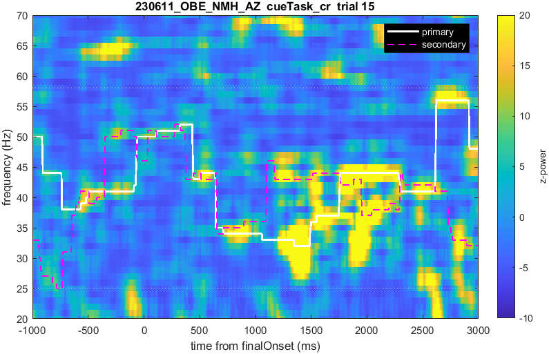

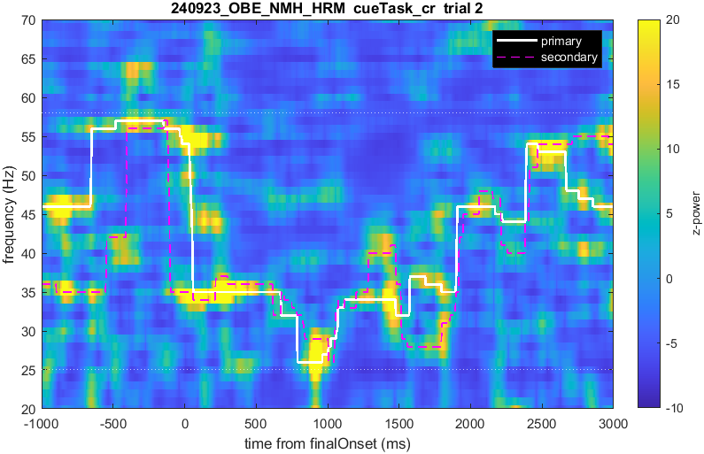

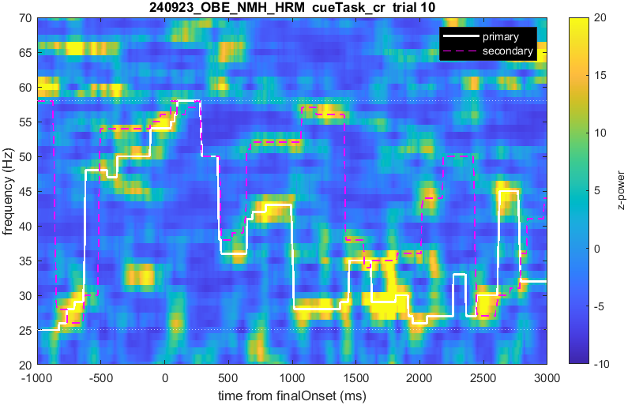

### Phase continuity (peak vs ridge)

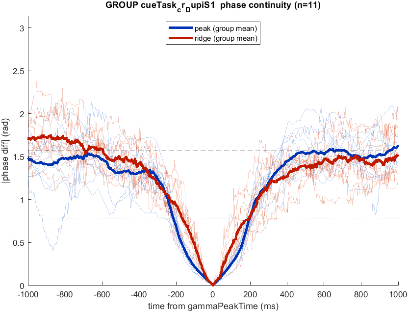

DupiS1 group

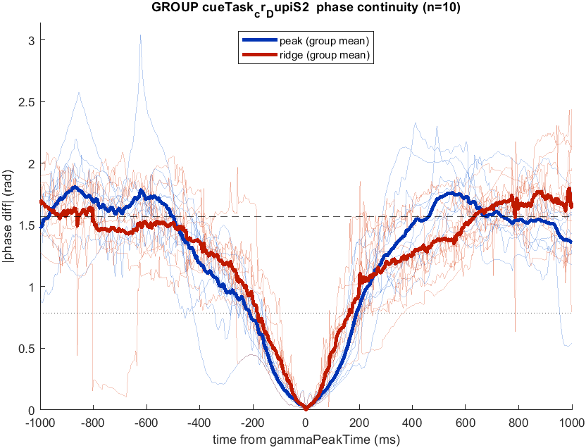

DupiS2 group

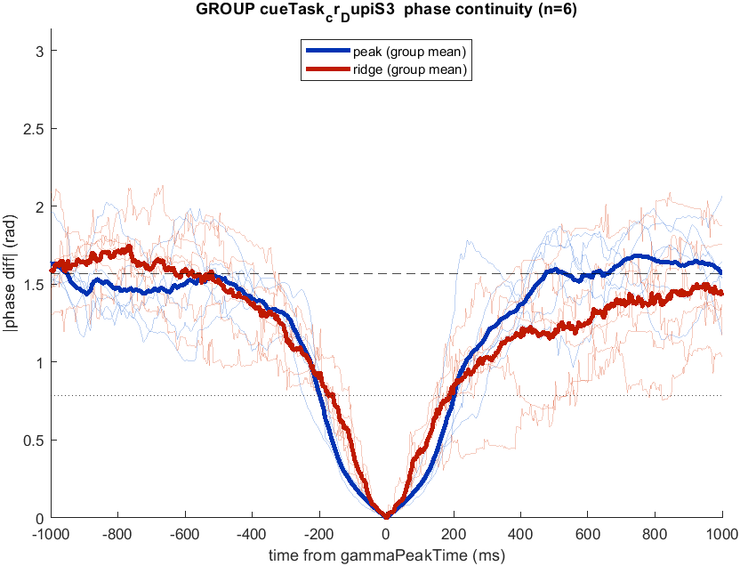

DupiS3 group

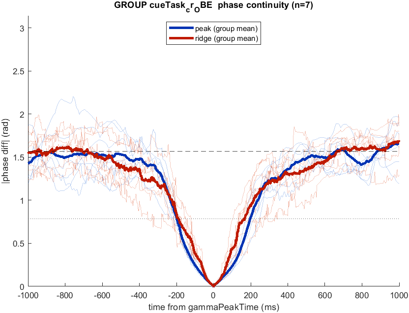

OBE group

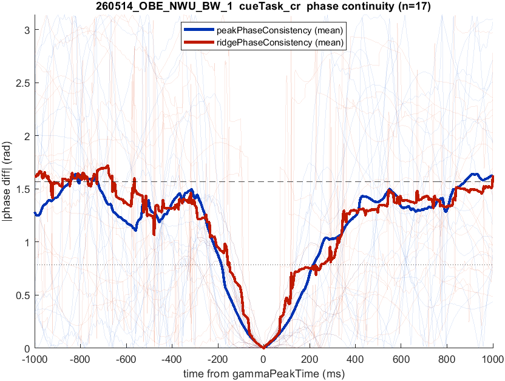

260514_OBE_NWU_BW_1

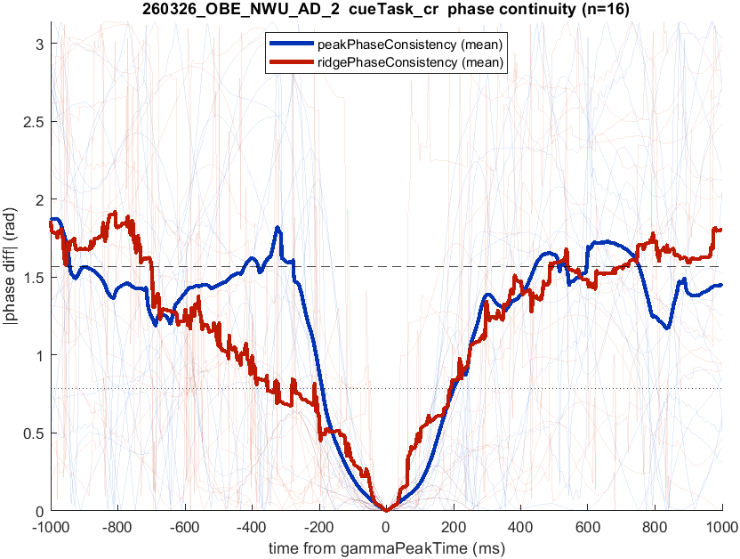

260326_OBE_NWU_AD_2

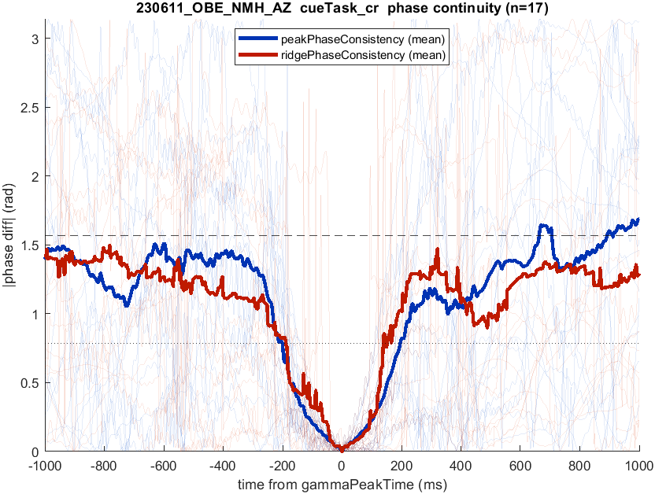

230611_OBE_NMH_AZ

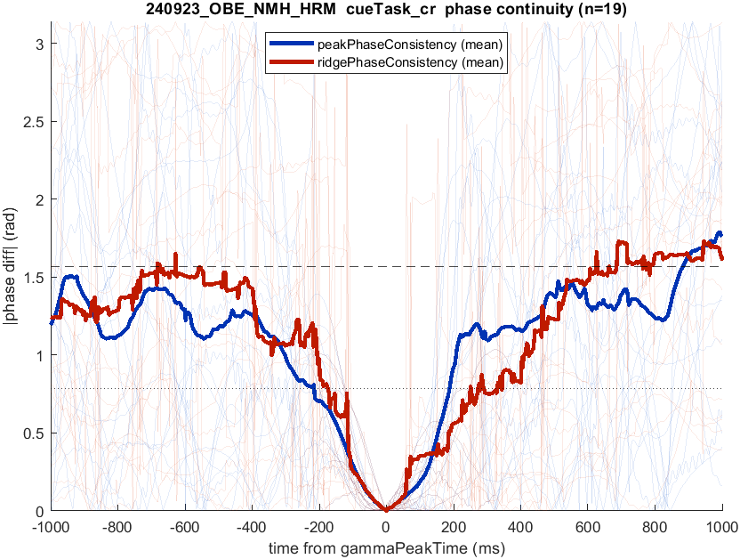

240923_OBE_NMH_HRM

- **DupiS1** (n=11 subj): peak vs ridge |phase diff| differ (max-stat perm, corrected p<0.05) at 44 timepoints, -170 to -64 ms.
- **DupiS2** (n=10 subj): peak vs ridge |phase diff| differ (max-stat perm, corrected p<0.05) at 14 timepoints, 90 to 120 ms.
- **DupiS3** (n=6 subj): no timepoints survive correction.
- **OBE** (n=7 subj): no timepoints survive correction.

### Burst length (peak vs ridge)

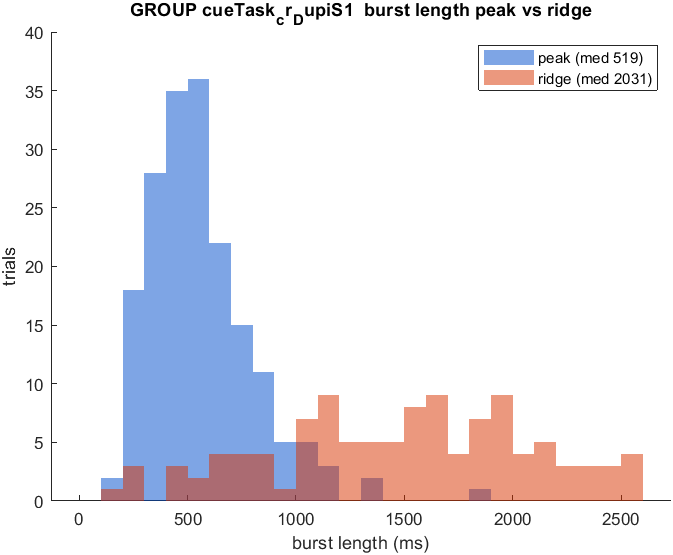

DupiS1 group

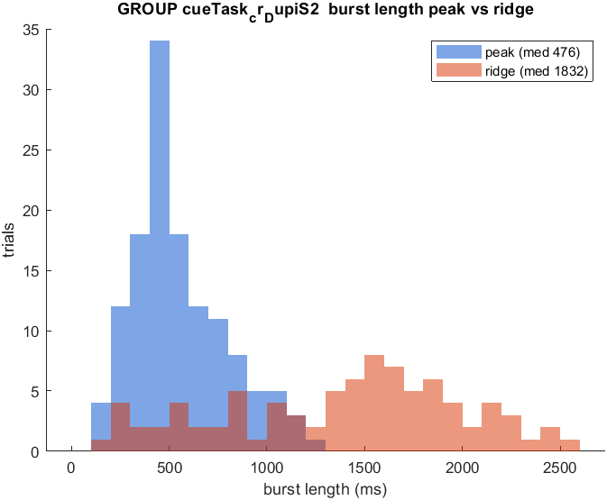

DupiS2 group

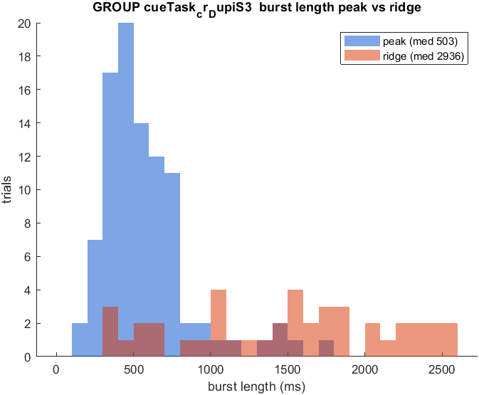

DupiS3 group

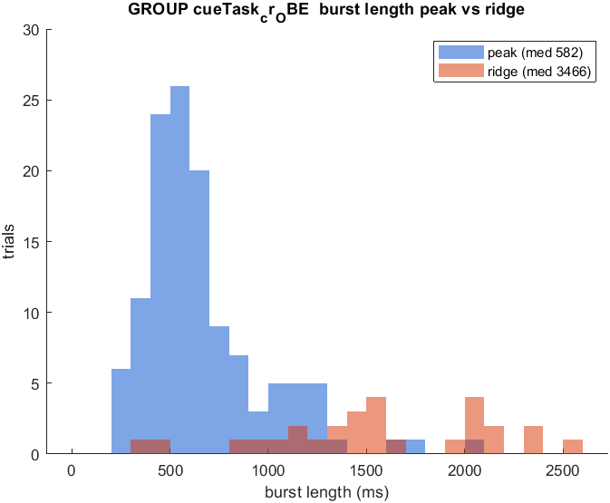

OBE group

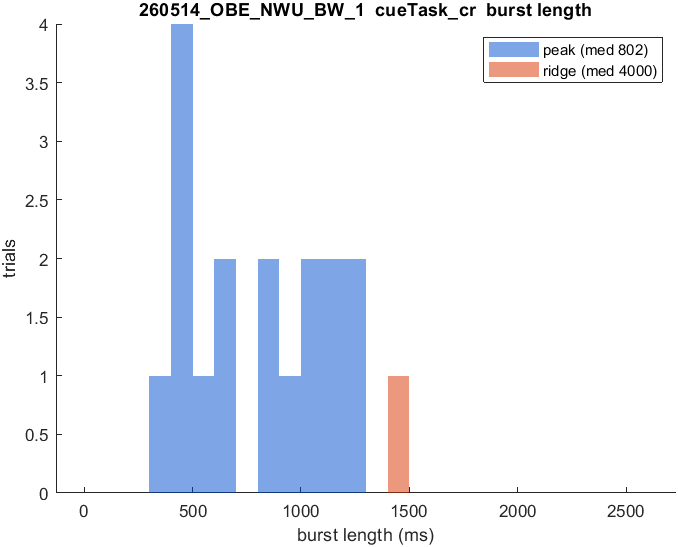

260514_OBE_NWU_BW_1

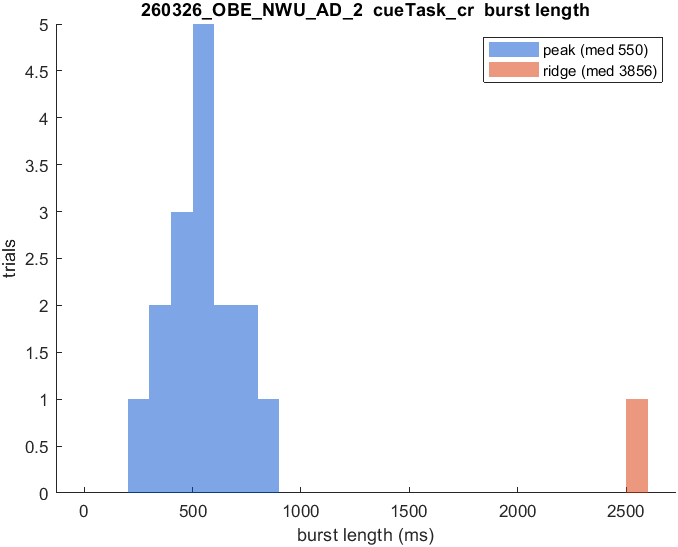

260326_OBE_NWU_AD_2

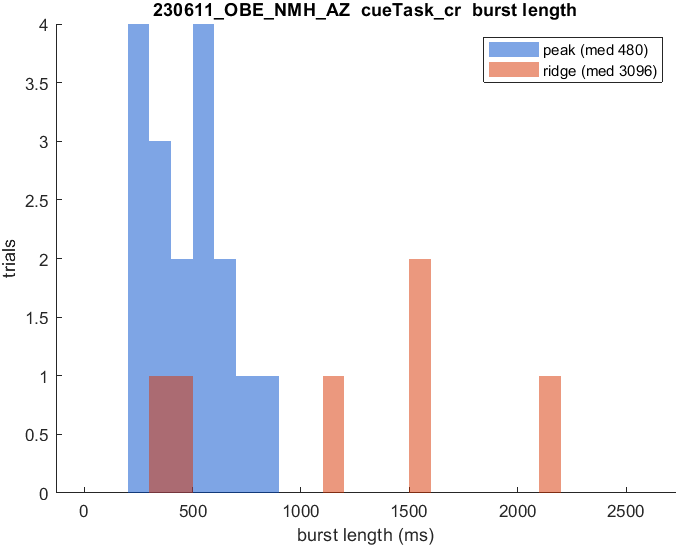

230611_OBE_NMH_AZ

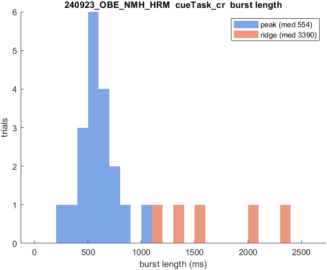

240923_OBE_NMH_HRM

- **DupiS1** (n=11): median peak 514 ms vs ridge 2048 ms; paired Wilcoxon p=0.0009766 (ridge−peak median diff 1482 ms).
- **DupiS2** (n=10): median peak 482 ms vs ridge 2275 ms; paired Wilcoxon p=0.001953 (ridge−peak median diff 1776 ms).
- **DupiS3** (n=6): median peak 573 ms vs ridge 2810 ms; paired Wilcoxon p=0.03125 (ridge−peak median diff 2236 ms).
- **OBE** (n=7): median peak 565 ms vs ridge 3390 ms; paired Wilcoxon p=0.01563 (ridge−peak median diff 2836 ms).

# Task: threshTask

## threshTask — air

### Group mean TFR & peak-aligned TFR

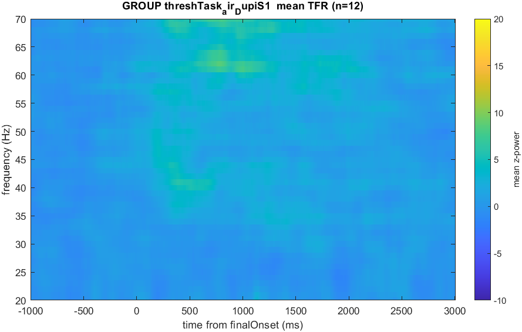

DupiS1 air mean TFR

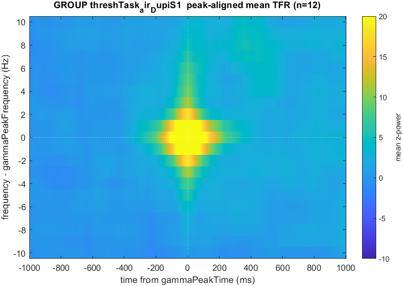

DupiS1 air peak-aligned

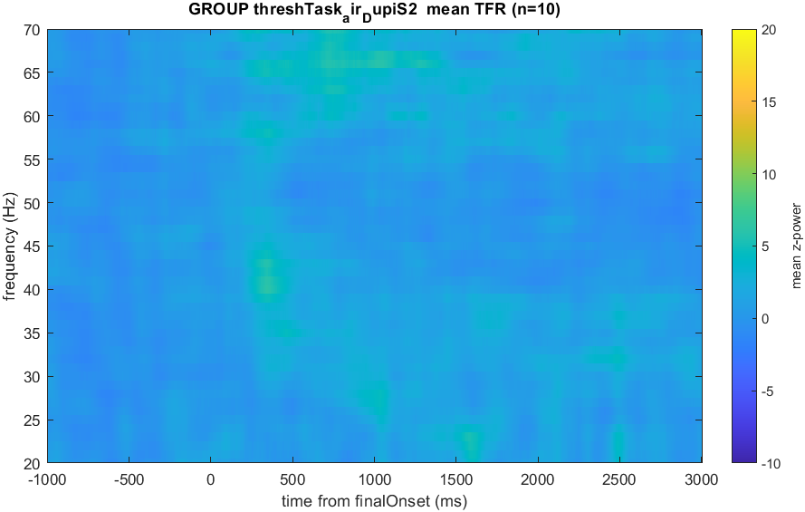

DupiS2 air mean TFR

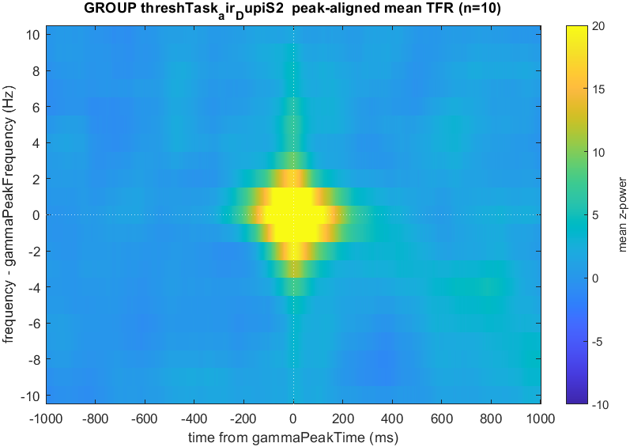

DupiS2 air peak-aligned

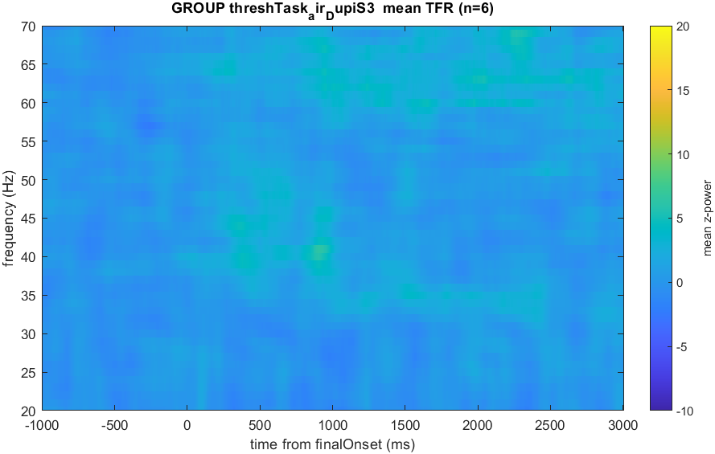

DupiS3 air mean TFR

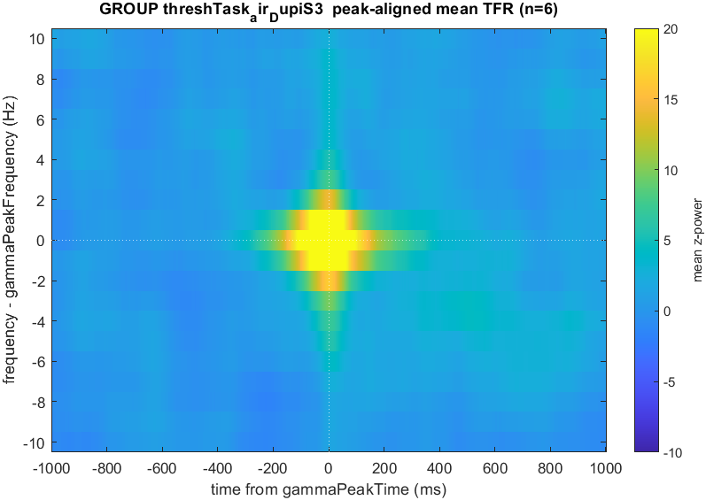

DupiS3 air peak-aligned

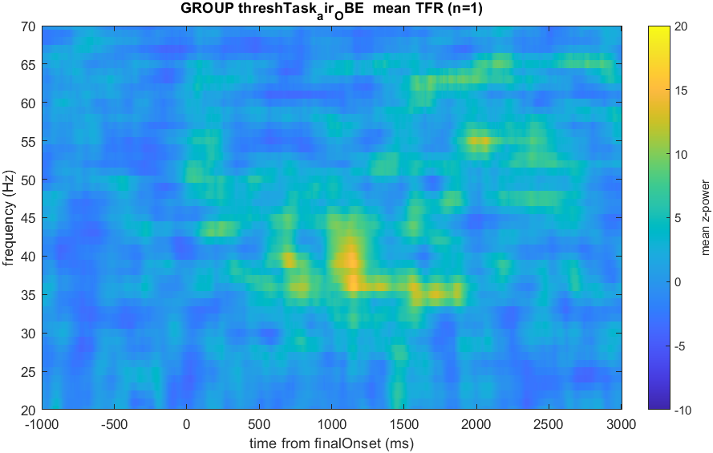

OBE air mean TFR

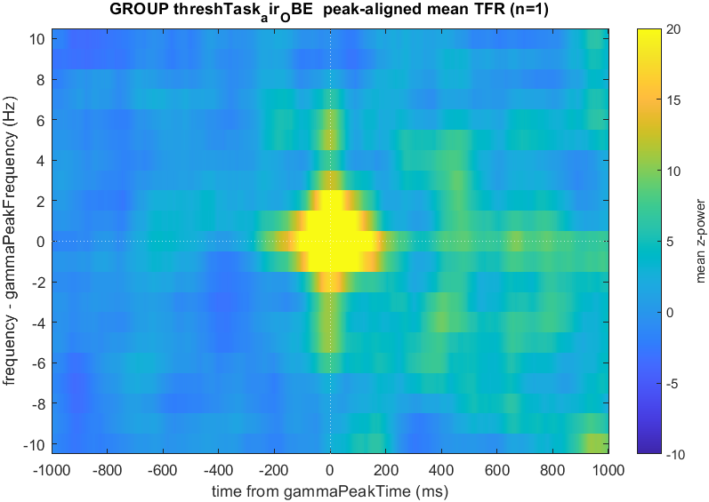

OBE air peak-aligned

### Single-trial examples (TFR + primary/secondary ridge)

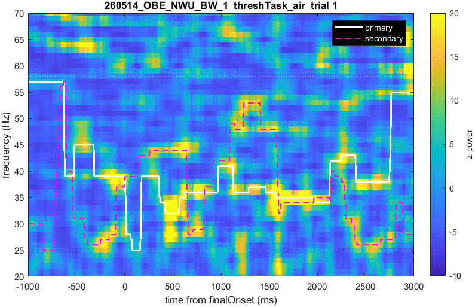

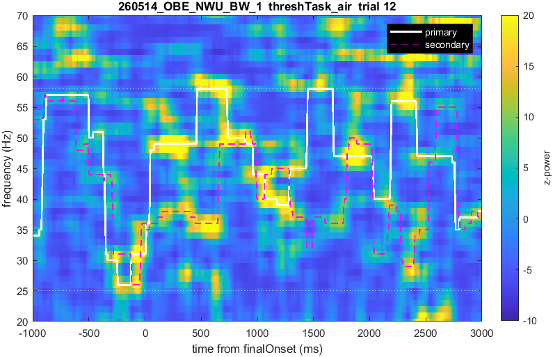

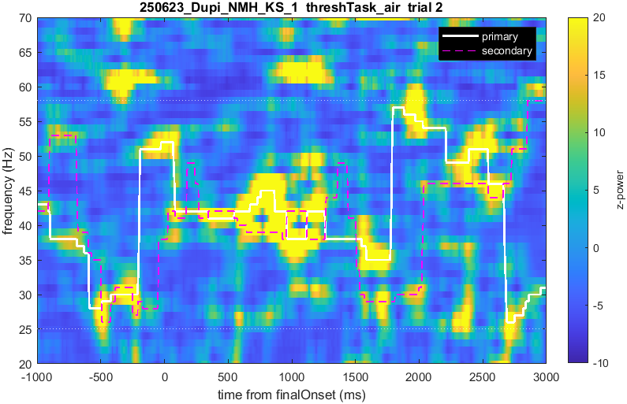

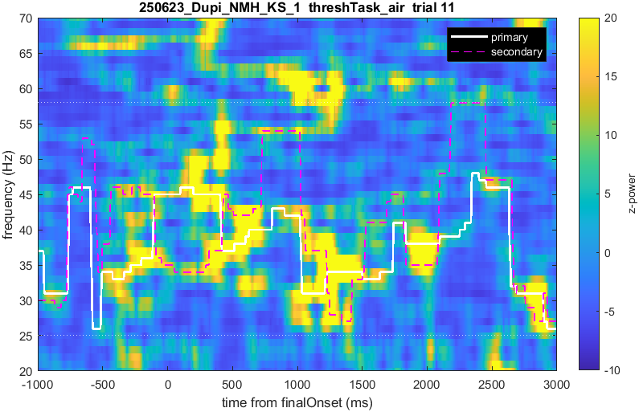

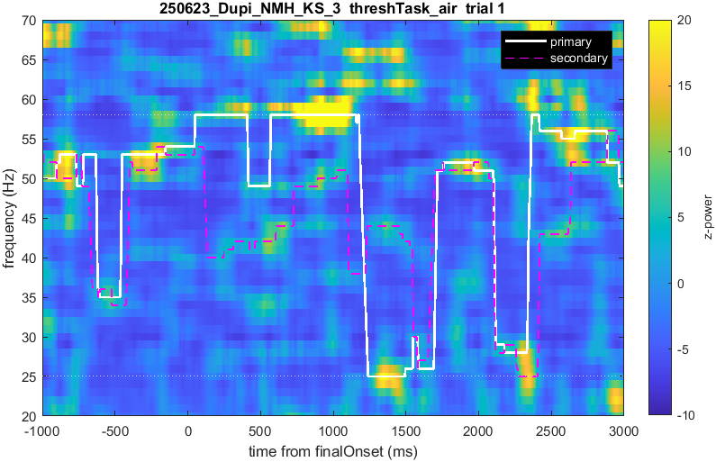

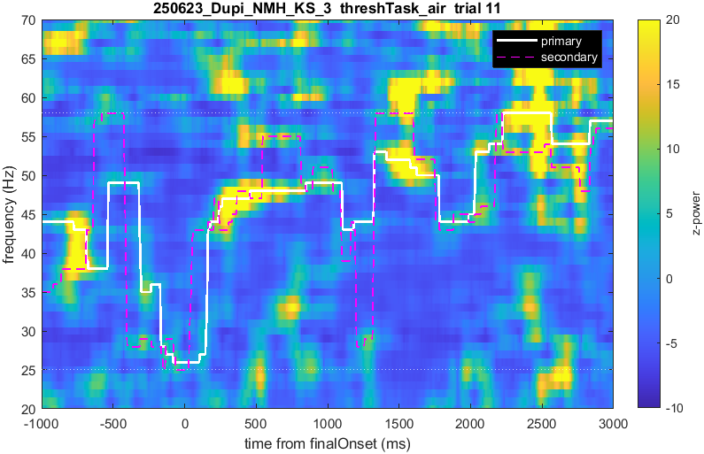

### Phase continuity (peak vs ridge)

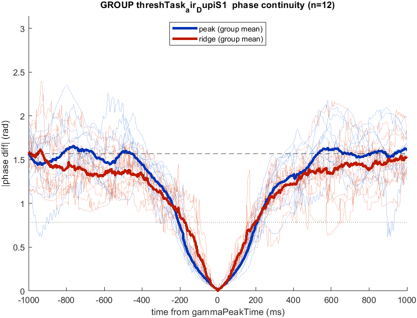

DupiS1 group

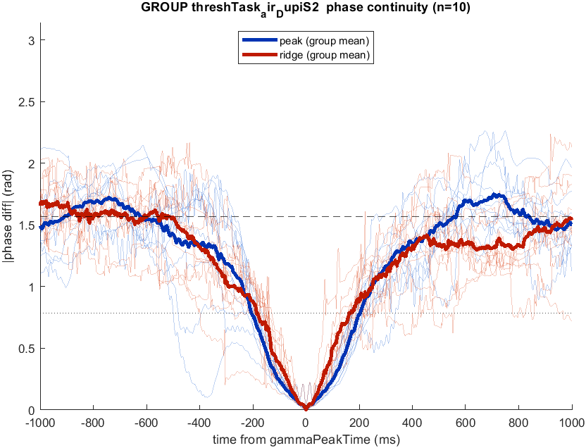

DupiS2 group

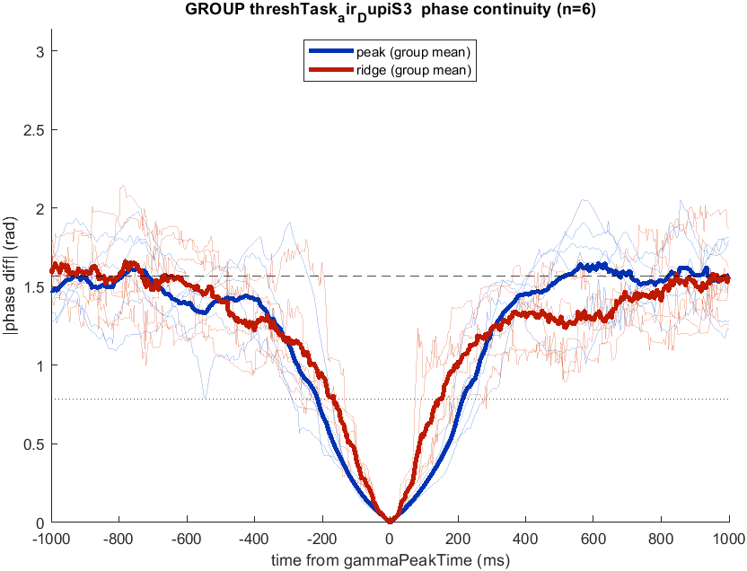

DupiS3 group

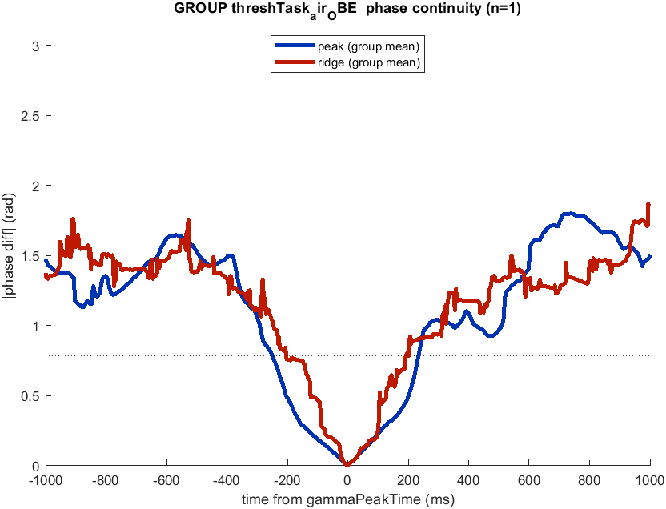

OBE group

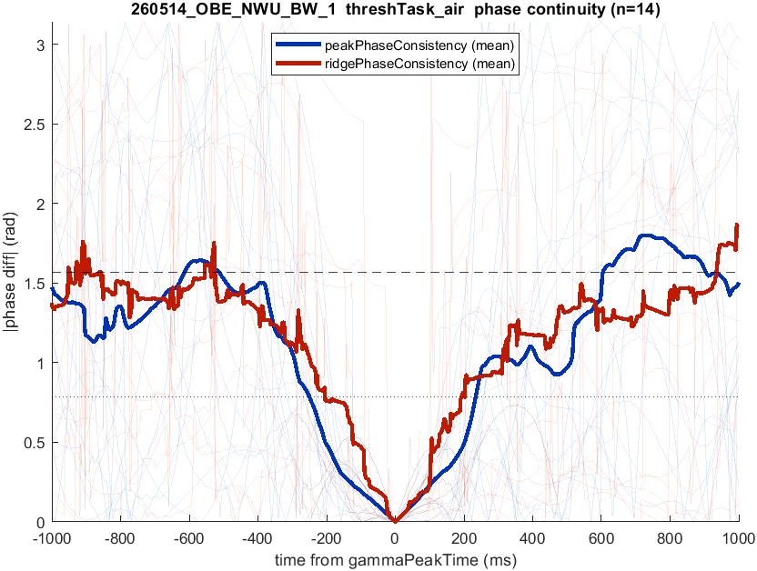

260514_OBE_NWU_BW_1

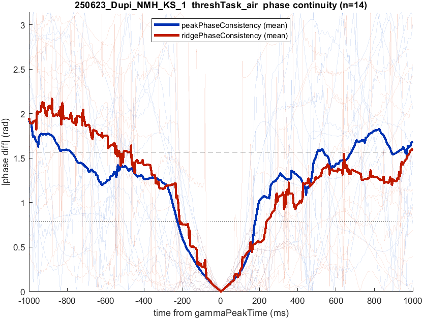

250623_Dupi_NMH_KS_1

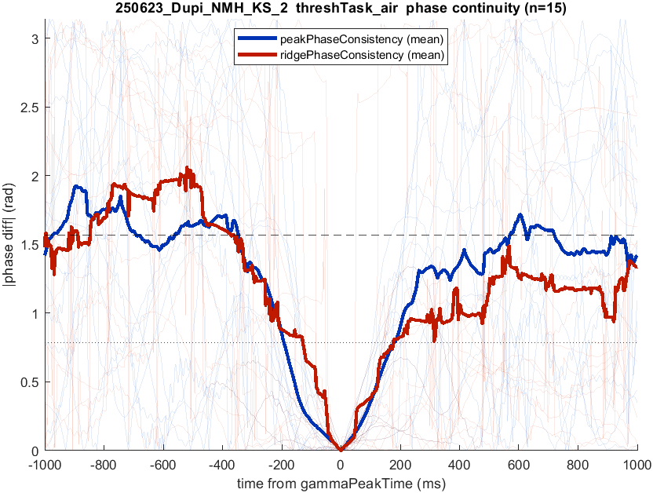

250623_DUPI_NMH_KS_2

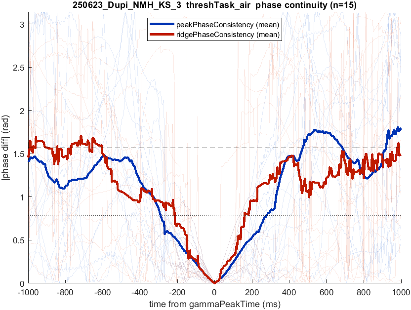

250623_Dupi_NMH_KS_3

- **DupiS1** (n=12 subj): peak vs ridge |phase diff| differ (max-stat perm, corrected p<0.05) at 16 timepoints, -84 to 134 ms.
- **DupiS2** (n=10 subj): peak vs ridge |phase diff| differ (max-stat perm, corrected p<0.05) at 33 timepoints, 696 to 764 ms.
- **DupiS3** (n=6 subj): no timepoints survive correction.
- **OBE** (n=1): too few subjects for stats.